# Tarea 2_Ricardo Zamora Mennigke_Mineria de Datos I

Ricardo Zamora Mennigke

4/1/2020

```r
knitr::opts_chunk$set(echo = TRUE)
```

```r
knitr::opts_chunk$set(error = TRUE)
```

```r
summary(cars)
```

```
##      speed           dist
##  Min.   : 4.0   Min.   :  2.00
##  1st Qu.:12.0   1st Qu.: 26.00
##  Median :15.0   Median : 36.00
##  Mean   :15.4   Mean   : 42.98
##  3rd Qu.:19.0   3rd Qu.: 56.00
##  Max.   :25.0   Max.   :120.00
```

#Tarea 02 #Mineria de Datos I #Ricardo Zamora Mennigke

```r
#install.packages("knitr",dependencies = T)
#install.packages("rmarkdown", dependencies = T)
#install.packages("tidyverse", dependencies = T)
#install.packages("kknn", dependencies = T)
#install.packages("ggplot2", dependencies = T)
library(knitr)
library(rmarkdown)
library(tidyverse)
library(kknn)
library(ggplot2)
```

#Ejercicio 1

##Programe en lenguaje R una funcion que reciba como entrada la matriz de confusion (para el caso 2 × 2) que calcule y retorne en una lista: la Precision Global, el Error Global, la Precision Positiva (PP), la Precision Negativa (PN), los Falsos Positivos (FP), los Falsos Negativos (FN), la Asertividad Positiva (AP) y la Asertividad Negativa (NP).

```r
indices.general <- function(MC) {
  precision.global <- sum(diag(MC))/sum(MC)
  error.global <- 1 - precision.global
  precision.categoria <- diag(MC)/rowSums(MC)
  precision.positiva <- MC[2, 2]/(MC[2, 2] + MC[2, 1])
  precision.negativa <- MC[1, 1]/(MC[1, 1] + MC[1, 2])
  falsos.positivos <- 1 - precision.negativa
  falsos.negativos <- 1 - precision.positiva
  asertividad.positiva <- MC[2, 2]/(MC[1, 2] + MC[2, 2])
  asertividad.negativa <- MC[1, 1]/(MC[1, 1] + MC[2, 1])
  res <- list(matriz.confusion = MC, precision.global = precision.global, error.global = error.global,
              precision.categoria = precision.categoria, precision.positiva = precision.positiva, precision.negativa=precision.negativa,
              falsos.positivos=falsos.positivos, falsos.negativos=falsos.negativos, asertividad.positiva=asertividad.positiva,
              asertividad.negativa=asertividad.negativa)
  names(res) <- c("Matriz de Confusión", "Precisión Global", "Error Global", "Precisión por categoría", "Precision Positiva", "Precision Negativa",
                  "Falsos Positivos", "Falsos Negativos", "Asertividad Positiva", "Asertividad Negativa")
  return(res)
}
```

##Supongamos que tenemos un modelo predictivo para detectar Fraude en Tarjetas de Credito, la variable a predecir es Fraude con dos posibles valores Sı (para el caso en que sı fue fraude) y No (para el caso en que no fue fraude). Supongamos la matriz de confusi´on es:

```r
MC <- matrix(c(892254, 212, 8993, 300),ncol=2,byrow=TRUE)
MC
```

```
##        [,1] [,2]
## [1,] 892254  212
## [2,]   8993  300
```

##Calcule la Precisi´on Global, el Error Global, la Precisi´on Positiva (PP), la Precisi´on Negativa (PN), los Falsos Positivos (FP), los Falsos Negativos (FN), la Asertividad Positiva (AP) y la Asertividad Negativa (NP).

```r
indices.general(MC)
```

```
## $`Matriz de Confusión`
##        [,1] [,2]
## [1,] 892254  212
## [2,]   8993  300
##
## $`Precisión Global`
## [1] 0.9897922
##
## $`Error Global`
## [1] 0.01020783
##
## $`Precisión por categoría`
## [1] 0.99976246 0.03228236
##
## $`Precision Positiva`
## [1] 0.03228236
##
## $`Precision Negativa`
## [1] 0.9997625
##
## $`Falsos Positivos`
## [1] 0.0002375441
##
## $`Falsos Negativos`
## [1] 0.9677176
##
## $`Asertividad Positiva`
## [1] 0.5859375
##
## $`Asertividad Negativa`
## [1] 0.9900216
```

##¿Es bueno o malo el modelo predictivo? Justifique su respuesta

#Inicialmente se puede entrar en el error de pensar que una precision global y un error global tan acertados indican que el modelo es adecuado. Pero para un mejor analisis un criterio experto primero senalaria inicialmente que existe una gran cantidad de falsos negativos, muy superior a los VP (verdaderos positivos), lo que indica que el modelo no esta identificando correctamente los Reales positivos por lo que el modelo ajustado no es bueno.

#Ejercicio 2

##En este ejercicio usaremos los datos (voces.csv). Se trata de un problema de reconocimiento de g´enero mediante el an´alisis de la voz y el habla. Esta base de datos fue creada para identificar una voz como masculina o femenina, bas´andose en las propiedades ac´usticas de la voz y el habla. El conjunto de datos consta de 3.168 muestras de voz grabadas, recogidas de hablantes masculinos y femeninos. Las muestras de voz se preprocesan mediante an´alisis ac´ustico en R, utilizando los paquetes de ondas marinas y de sinton´ıa de R, con un rango de frecuencia analizada de 0hz-280hz (rango vocal humano). El conjunto de datos tiene las siguientes propiedades ac´usticas (variables) de cada voz:

##Cargue la tabla de datos voces.csv en R. No olvide recodificar la variable a predecir como categorica.

```r
setwd("C:/Users/rzamoram/Documents/Machine Learning/Mineria de Datos I/Clase2")
datos<-read.csv("voces.csv",dec='.',header=T)
str(datos)
```

```
## 'data.frame':    3168 obs. of  21 variables:
##  $ meanfreq: num  0.0598 0.066 0.0773 0.1512 0.1351 ...
##  $ sd      : num  0.0642 0.0673 0.0838 0.0721 0.0791 ...
##  $ median  : num  0.032 0.0402 0.0367 0.158 0.1247 ...
##  $ Q25     : num  0.0151 0.0194 0.0087 0.0966 0.0787 ...
##  $ Q75     : num  0.0902 0.0927 0.1319 0.208 0.206 ...
##  $ IQR     : num  0.0751 0.0733 0.1232 0.1114 0.1273 ...
##  $ skew    : num  12.86 22.42 30.76 1.23 1.1 ...
##  $ kurt    : num  274.4 634.61 1024.93 4.18 4.33 ...
##  $ sp.ent  : num  0.893 0.892 0.846 0.963 0.972 ...
##  $ sfm     : num  0.492 0.514 0.479 0.727 0.784 ...
##  $ mode    : num  0 0 0 0.0839 0.1043 ...
##  $ centroid: num  0.0598 0.066 0.0773 0.1512 0.1351 ...
##  $ meanfun : num  0.0843 0.1079 0.0987 0.089 0.1064 ...
##  $ minfun  : num  0.0157 0.0158 0.0157 0.0178 0.0169 ...
##  $ maxfun  : num  0.276 0.25 0.271 0.25 0.267 ...
##  $ meandom : num  0.00781 0.00901 0.00799 0.2015 0.71281 ...
##  $ mindom  : num  0.00781 0.00781 0.00781 0.00781 0.00781 ...
##  $ maxdom  : num  0.00781 0.05469 0.01562 0.5625 5.48438 ...
##  $ dfrange : num  0 0.04688 0.00781 0.55469 5.47656 ...
##  $ modindx : num  0 0.0526 0.0465 0.2471 0.2083 ...
##  $ genero  : Factor w/ 2 levels "Femenino","Masculino": 2 2 2 2 2 2 2 2 2 2 ...
```

##Realice un analisis exploratorio (estadısticas basicas) que incluya: el resumen numerico (media, desviacion estandar, etc.), los valores atıpicos, la correlacion entre las variables, el poder predictivo de las variables predictoras. Interprete los resultados.

#Estadisticas basicas

```r
summary(datos)
```

```
##     meanfreq             sd              median             Q25
##  Min.   :0.03936   Min.   :0.01836   Min.   :0.01097   Min.   :0.0002288
##  1st Qu.:0.16366   1st Qu.:0.04195   1st Qu.:0.16959   1st Qu.:0.1110865
##  Median :0.18484   Median :0.05916   Median :0.19003   Median :0.1402864
##  Mean   :0.18091   Mean   :0.05713   Mean   :0.18562   Mean   :0.1404556
##  3rd Qu.:0.19915   3rd Qu.:0.06702   3rd Qu.:0.21062   3rd Qu.:0.1759388
##  Max.   :0.25112   Max.   :0.11527   Max.   :0.26122   Max.   :0.2473469
##       Q75               IQR               skew              kurt
##  Min.   :0.04295   Min.   :0.01456   Min.   : 0.1417   Min.   :   2.068
##  1st Qu.:0.20875   1st Qu.:0.04256   1st Qu.: 1.6496   1st Qu.:   5.670
##  Median :0.22568   Median :0.09428   Median : 2.1971   Median :   8.319
##  Mean   :0.22476   Mean   :0.08431   Mean   : 3.1402   Mean   :  36.569
##  3rd Qu.:0.24366   3rd Qu.:0.11418   3rd Qu.: 2.9317   3rd Qu.:  13.649
##  Max.   :0.27347   Max.   :0.25223   Max.   :34.7255   Max.   :1309.613
##      sp.ent            sfm               mode           centroid
##  Min.   :0.7387   Min.   :0.03688   Min.   :0.0000   Min.   :0.03936
##  1st Qu.:0.8618   1st Qu.:0.25804   1st Qu.:0.1180   1st Qu.:0.16366
##  Median :0.9018   Median :0.39634   Median :0.1866   Median :0.18484
##  Mean   :0.8951   Mean   :0.40822   Mean   :0.1653   Mean   :0.18091
##  3rd Qu.:0.9287   3rd Qu.:0.53368   3rd Qu.:0.2211   3rd Qu.:0.19915
##  Max.   :0.9820   Max.   :0.84294   Max.   :0.2800   Max.   :0.25112
##     meanfun            minfun             maxfun          meandom
##  Min.   :0.05557   Min.   :0.009775   Min.   :0.1031   Min.   :0.007812
##  1st Qu.:0.11700   1st Qu.:0.018223   1st Qu.:0.2540   1st Qu.:0.419828
##  Median :0.14052   Median :0.046110   Median :0.2712   Median :0.765795
##  Mean   :0.14281   Mean   :0.036802   Mean   :0.2588   Mean   :0.829211
##  3rd Qu.:0.16958   3rd Qu.:0.047904   3rd Qu.:0.2775   3rd Qu.:1.177166
##  Max.   :0.23764   Max.   :0.204082   Max.   :0.2791   Max.   :2.957682
##      mindom             maxdom             dfrange          modindx
##  Min.   :0.004883   Min.   : 0.007812   Min.   : 0.000   Min.   :0.00000
##  1st Qu.:0.007812   1st Qu.: 2.070312   1st Qu.: 2.045   1st Qu.:0.09977
##  Median :0.023438   Median : 4.992188   Median : 4.945   Median :0.13936
##  Mean   :0.052647   Mean   : 5.047277   Mean   : 4.995   Mean   :0.17375
##  3rd Qu.:0.070312   3rd Qu.: 7.007812   3rd Qu.: 6.992   3rd Qu.:0.20918
##  Max.   :0.458984   Max.   :21.867188   Max.   :21.844   Max.   :0.93237
##        genero
##  Femenino :1584
##  Masculino:1584
##
##
##
##
```

#Valores atipicos

##mas datos atipicos en kurt

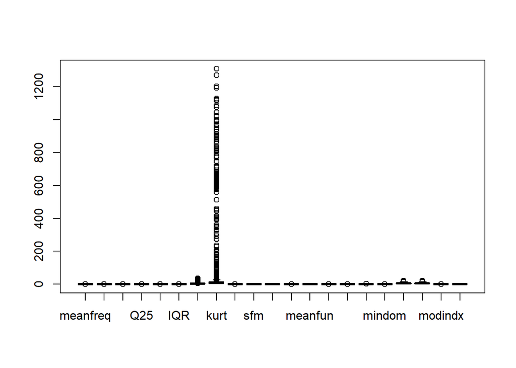

```r
boxplot(datos)
```

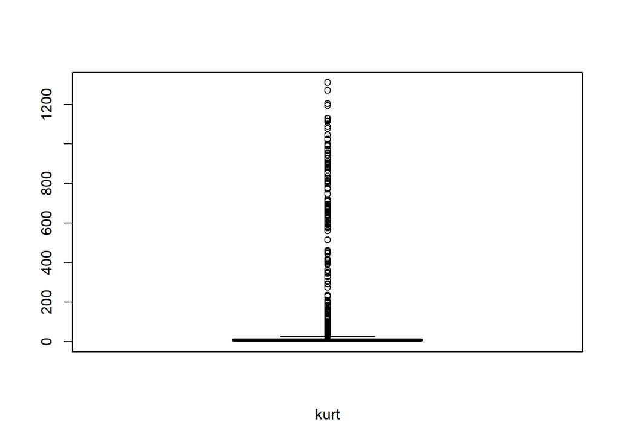

```r
boxplot(datos$kurt, xlab = "kurt")
```

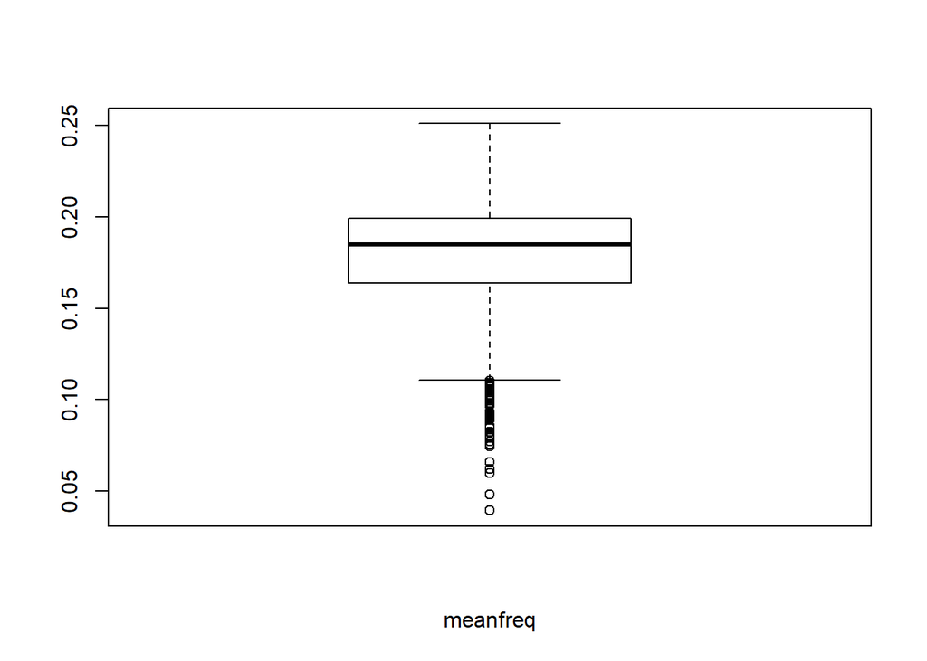

```r
boxplot(datos$meanfreq, xlab = "meanfreq")
```

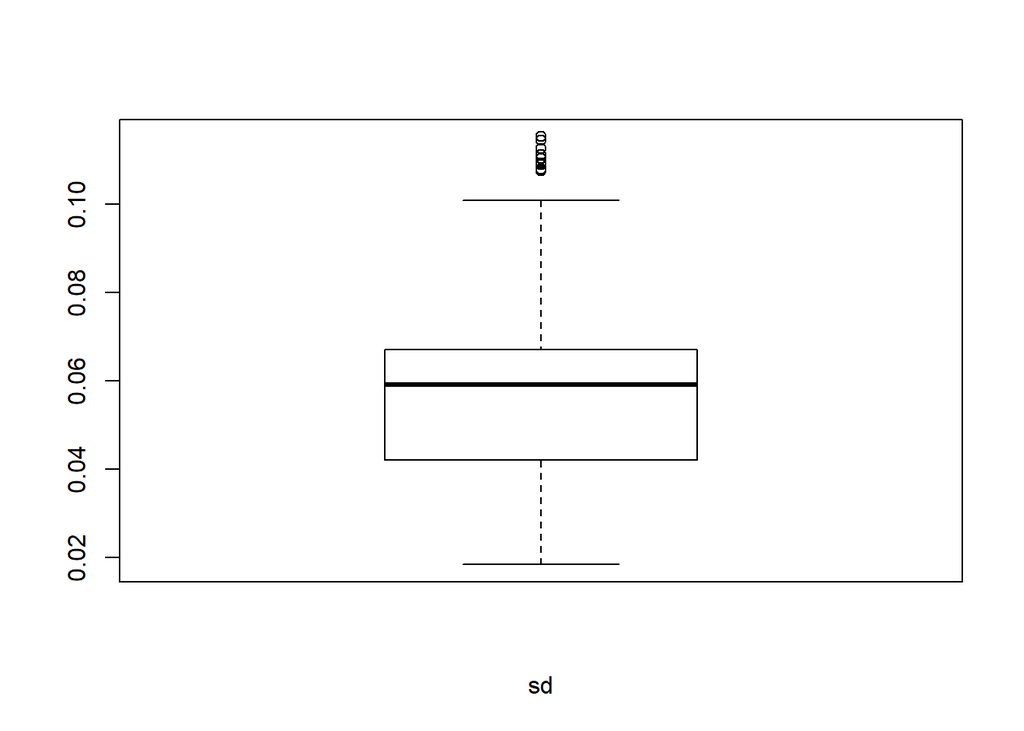

```r
boxplot(datos$sd, xlab = "sd")
```

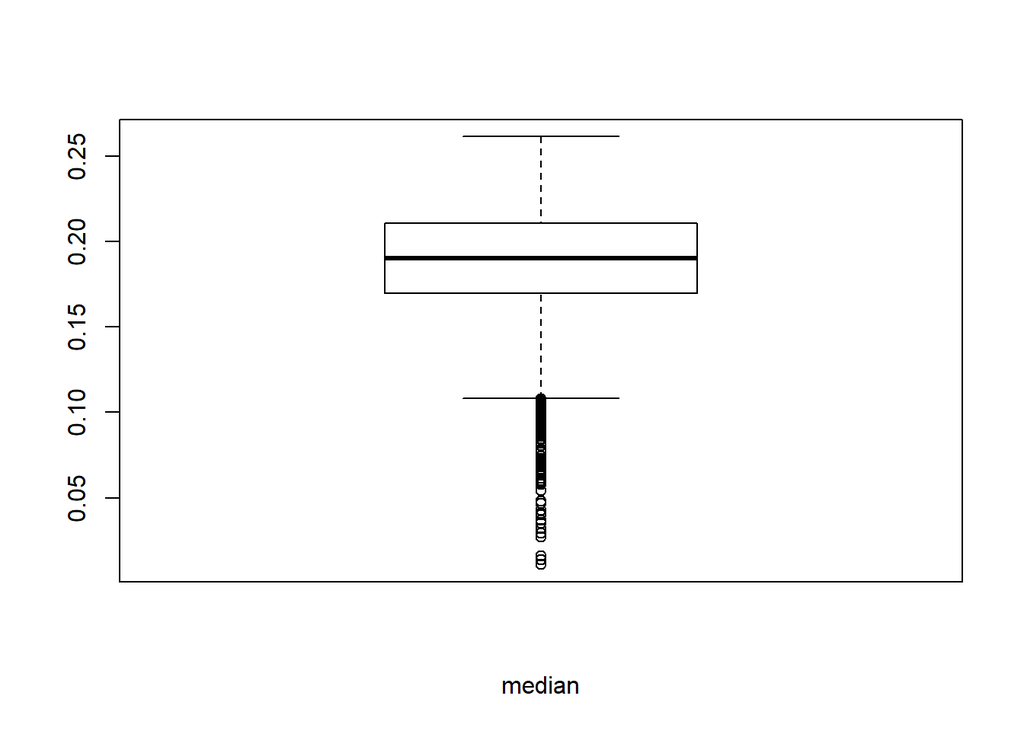

```r
boxplot(datos$median, xlab = "median")
```

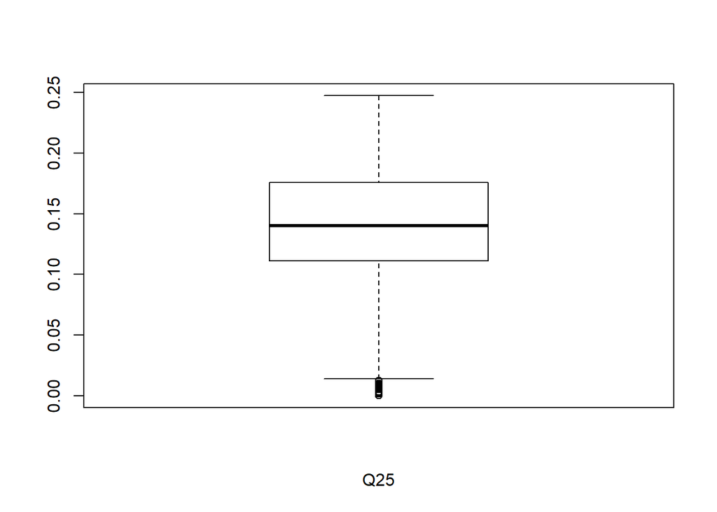

```r
boxplot(datos$Q25, xlab = "Q25")
```

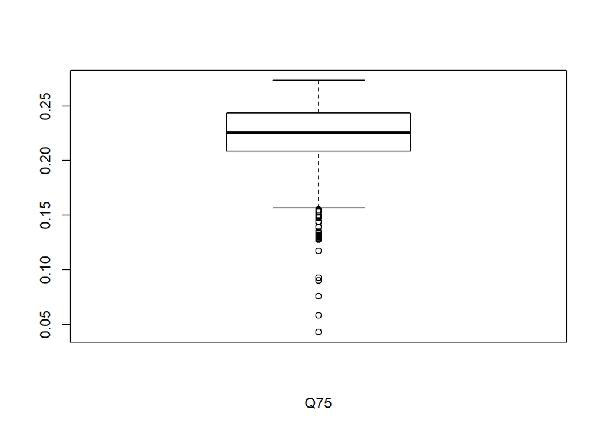

```r
boxplot(datos$Q75, xlab = "Q75")
```

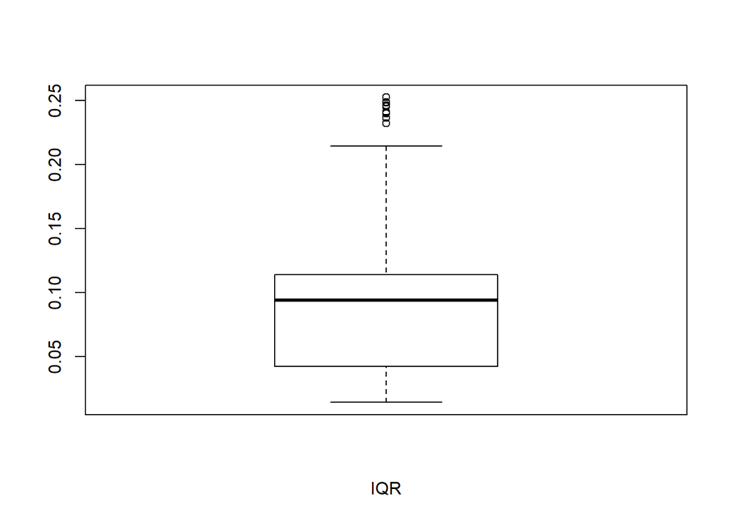

```r
boxplot(datos$IQR, xlab = "IQR")
```

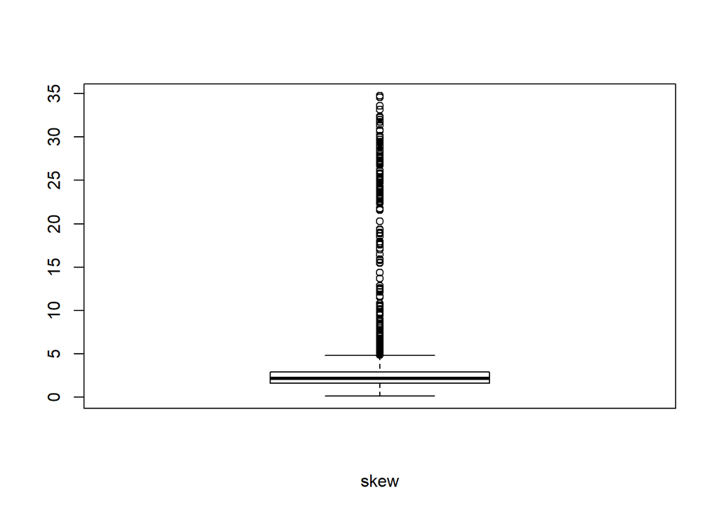

```r
boxplot(datos$skew, xlab = "skew")
```

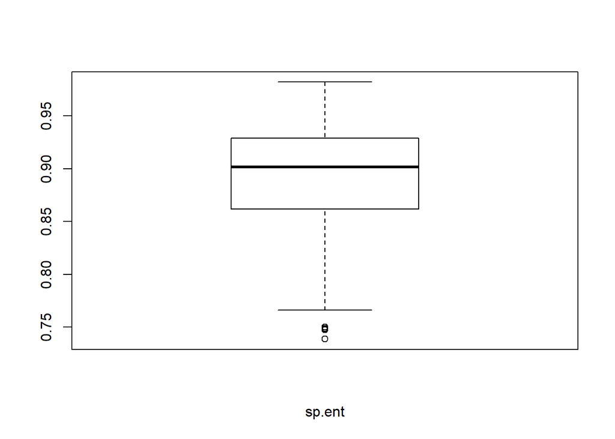

```r
boxplot(datos$sp.ent, xlab = "sp.ent")
```

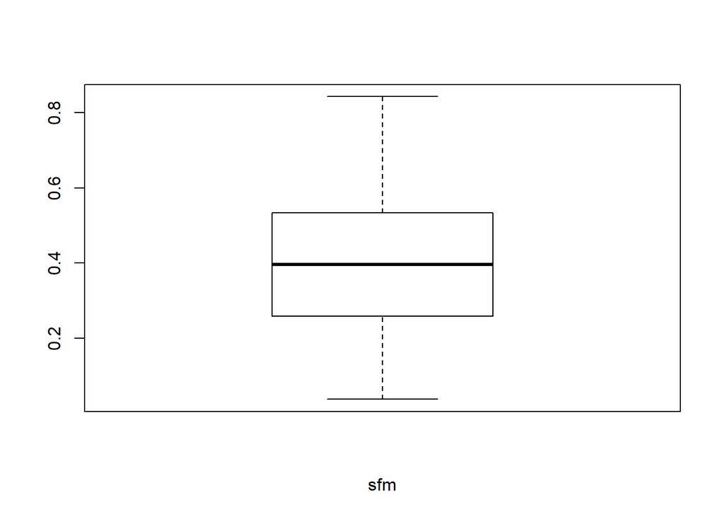

```r
boxplot(datos$sfm, xlab = "sfm")
```

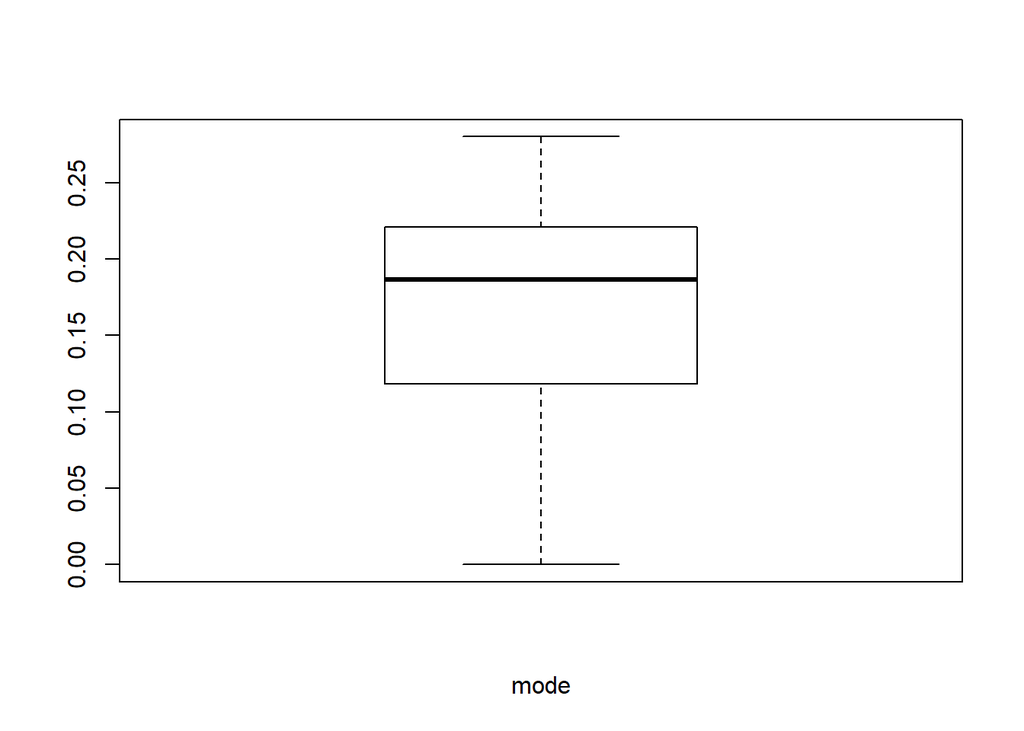

```r
boxplot(datos$mode, xlab = "mode")
```

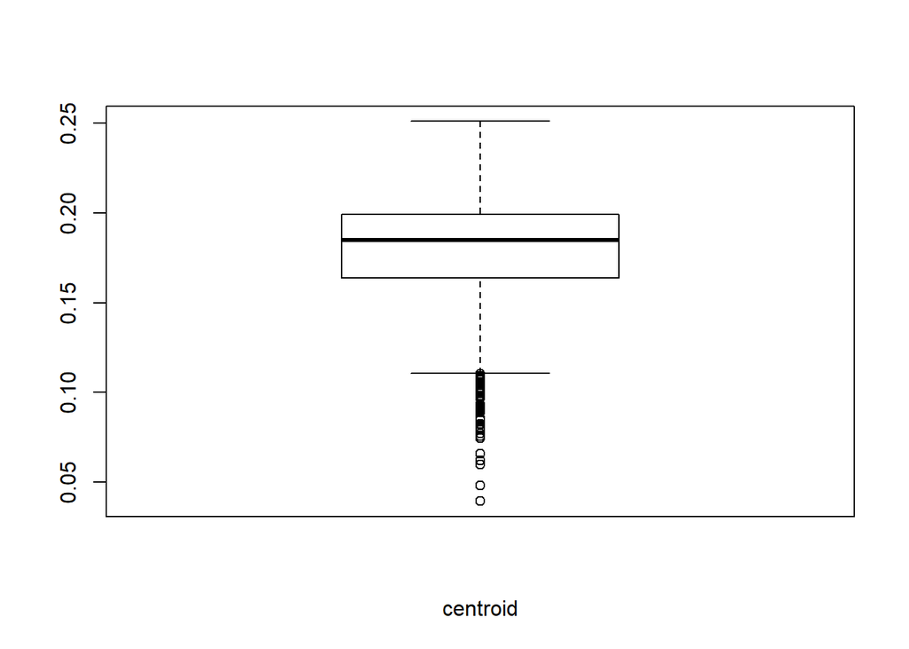

```r
boxplot(datos$centroid, xlab = "centroid")
```

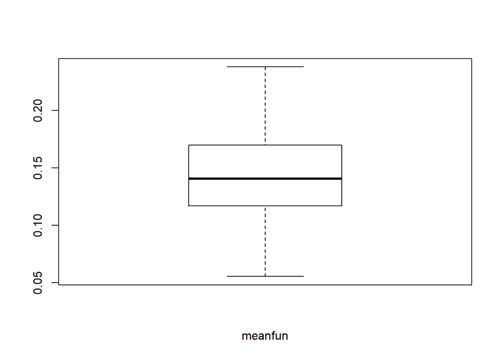

```r
boxplot(datos$meanfun, xlab = "meanfun")
```

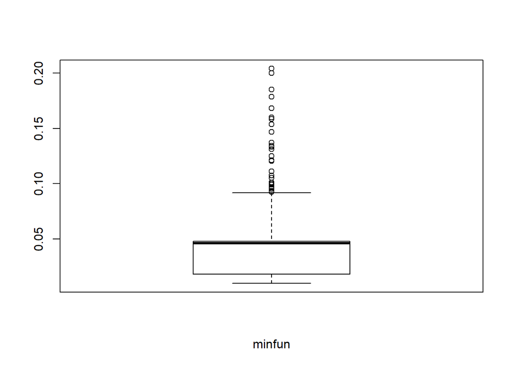

```r
boxplot(datos$minfun, xlab = "minfun")
```

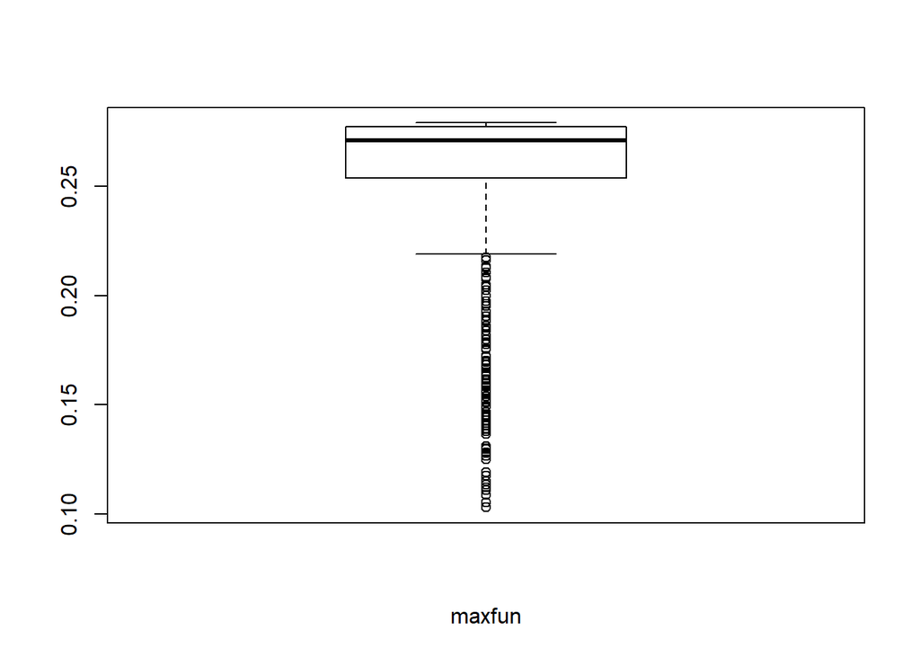

```r
boxplot(datos$maxfun, xlab = "maxfun")
```

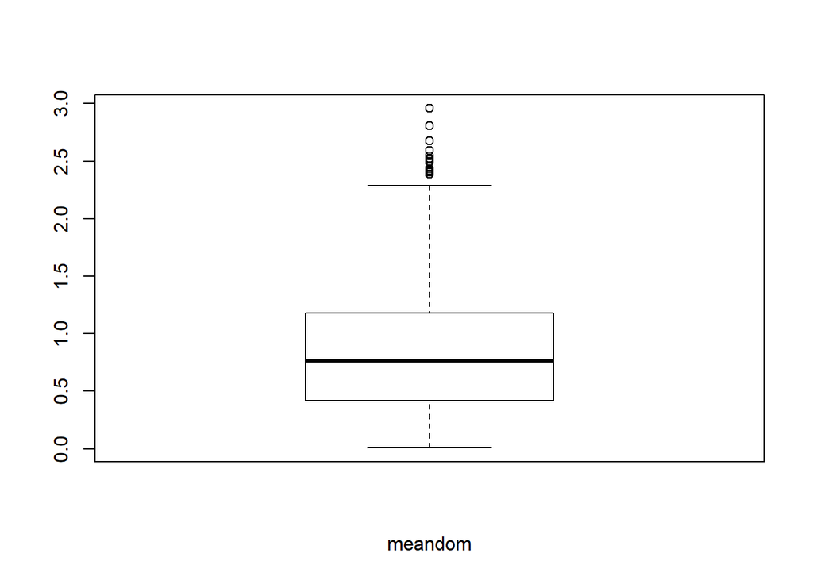

```r
boxplot(datos$meandom, xlab = "meandom")
```

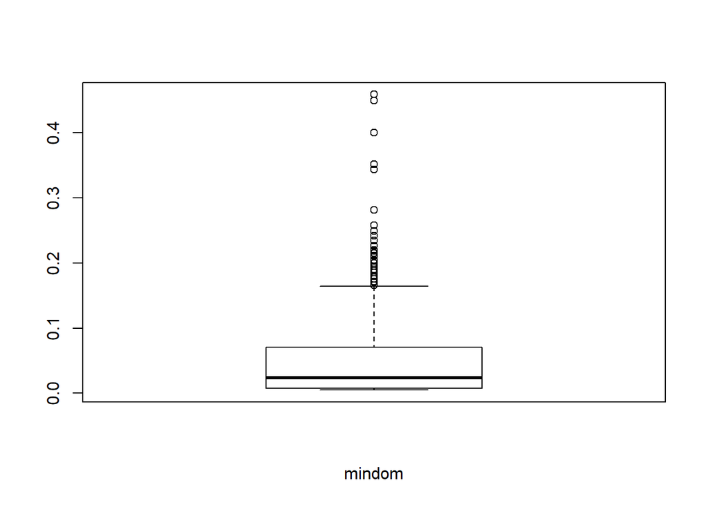

```r
boxplot(datos$mindom, xlab = "mindom")
```

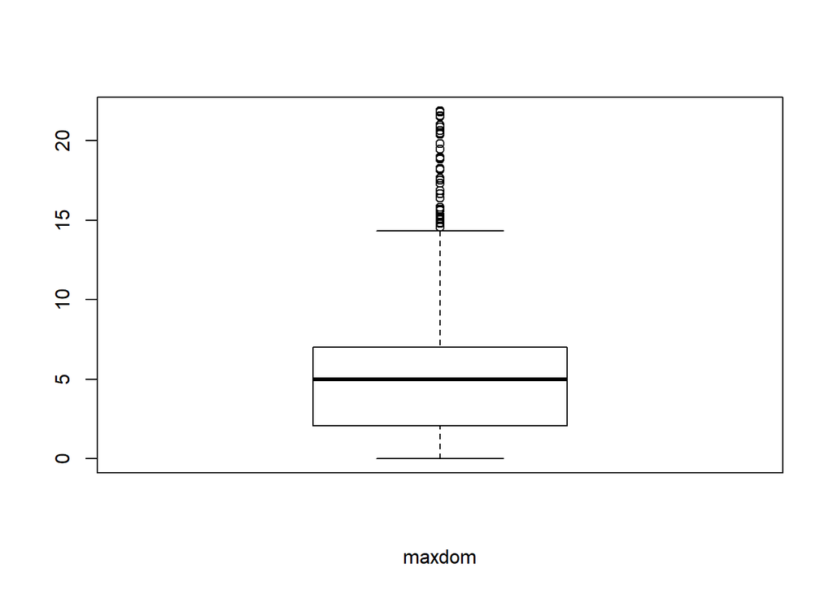

```r
boxplot(datos$maxdom, xlab = "maxdom")
```

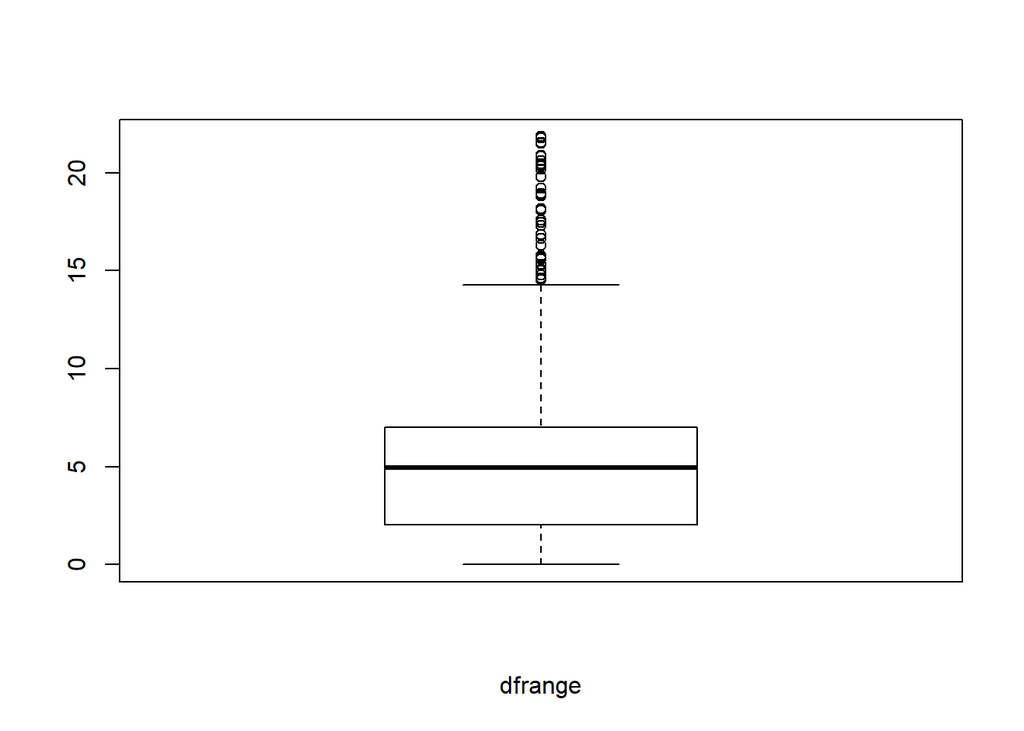

```r
boxplot(datos$dfrange, xlab = "dfrange")
```

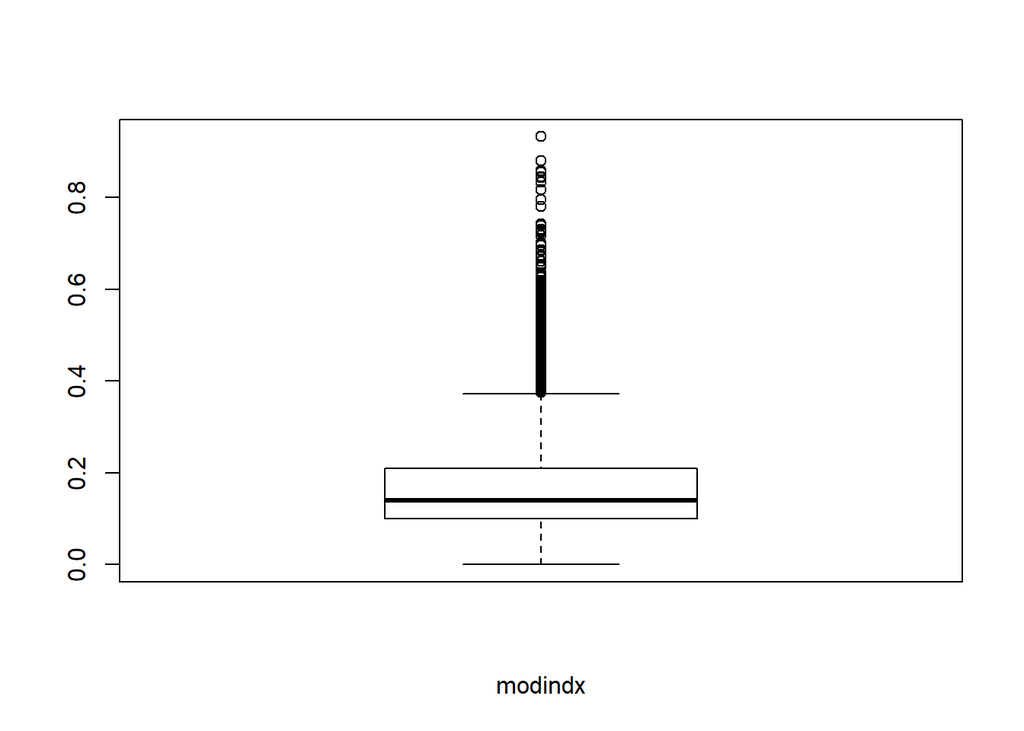

```r
boxplot(datos$modindx, xlab = "modindx")
```

```r
datos2 <- datos[,(-21)]
cor(datos2)
```

```
##            meanfreq         sd     median        Q25          Q75          IQR
## meanfreq  1.0000000 -0.7390388  0.9254454  0.9114163  0.740996718 -0.627605054
## sd       -0.7390388  1.0000000 -0.5626026 -0.8469309 -0.161075841  0.874660319
## median    0.9254454 -0.5626026  1.0000000  0.7749216  0.731849232 -0.477352003
## Q25       0.9114163 -0.8469309  0.7749216  1.0000000  0.477139811 -0.874188990
## Q75       0.7409967 -0.1610758  0.7318492  0.4771398  1.000000000  0.009635774
## IQR      -0.6276051  0.8746603 -0.4773520 -0.8741890  0.009635774  1.000000000
## skew     -0.3223269  0.3145970 -0.2574071 -0.3194753 -0.206338932  0.249497476
## kurt     -0.3160356  0.3462409 -0.2433816 -0.3501824 -0.148880617  0.316184735
## sp.ent   -0.6012025  0.7166200 -0.5020049 -0.6481258 -0.174905239  0.640813242
## sfm      -0.7843323  0.8380865 -0.6616899 -0.7668745 -0.378198373  0.663601458
## mode      0.6877152 -0.5291500  0.6774327  0.5912770  0.486857375 -0.403763599
## centroid  1.0000000 -0.7390388  0.9254454  0.9114163  0.740996718 -0.627605054
## meanfun   0.4608444 -0.4662815  0.4149093  0.5450351  0.155090956 -0.534461948
## minfun    0.3839368 -0.3456089  0.3376019  0.3209943  0.258002476 -0.222679719
## maxfun    0.2740041 -0.1296619  0.2513280  0.1998407  0.285583560 -0.069588302
## meandom   0.5366661 -0.4827262  0.4559427  0.4674028  0.359180617 -0.333362476
## mindom    0.2292610 -0.3576670  0.1911687  0.3022549 -0.023750103 -0.357036676
## maxdom    0.5195277 -0.4822778  0.4389190  0.4596832  0.335114045 -0.337876663
## dfrange   0.5155699 -0.4759991  0.4356207  0.4543938  0.335647521 -0.331563477
## modindx  -0.2169787  0.1226597 -0.2132975 -0.1413774 -0.216474678  0.041252438
##                 skew        kurt     sp.ent         sfm       mode   centroid
## meanfreq -0.32232693 -0.31603555 -0.6012025 -0.78433231  0.6877152  1.0000000
## sd        0.31459695  0.34624087  0.7166200  0.83808650 -0.5291500 -0.7390388
## median   -0.25740709 -0.24338163 -0.5020049 -0.66168990  0.6774327  0.9254454
## Q25      -0.31947531 -0.35018239 -0.6481258 -0.76687452  0.5912770  0.9114163
## Q75      -0.20633893 -0.14888062 -0.1749052 -0.37819837  0.4868574  0.7409967
## IQR       0.24949748  0.31618474  0.6408132  0.66360146 -0.4037636 -0.6276051
## skew      1.00000000  0.97702046 -0.1954592  0.07969407 -0.4348591 -0.3223269
## kurt      0.97702046  1.00000000 -0.1276436  0.10988403 -0.4067219 -0.3160356
## sp.ent   -0.19545924 -0.12764358  1.0000000  0.86641084 -0.3252985 -0.6012025
## sfm       0.07969407  0.10988403  0.8664108  1.00000000 -0.4859129 -0.7843323
## mode     -0.43485906 -0.40672189 -0.3252985 -0.48591287  1.0000000  0.6877152
## centroid -0.32232693 -0.31603555 -0.6012025 -0.78433231  0.6877152  1.0000000
## meanfun  -0.16766801 -0.19455985 -0.5131937 -0.42106568  0.3247713  0.4608444
## minfun   -0.21695429 -0.20320141 -0.3058260 -0.36210032  0.3854673  0.3839368
## maxfun   -0.08086107 -0.04566725 -0.1207380 -0.19236944  0.1723288  0.2740041
## meandom  -0.33684839 -0.30323357 -0.2935624 -0.42844249  0.4914794  0.5366661
## mindom   -0.06160765 -0.10331264 -0.2948689 -0.28959288  0.1981496  0.2292610
## maxdom   -0.30565086 -0.27450011 -0.3242531 -0.43664879  0.4771867  0.5195277
```

[output cut: 29 more lines]

```
## IQR      -0.33787666 -0.33156348  0.041252438
## skew     -0.30565086 -0.30464003 -0.169324710
## kurt     -0.27450011 -0.27272943 -0.205539321
## sp.ent   -0.32425314 -0.31905357  0.198074268
## sfm      -0.43664879 -0.43157977  0.211477226
## mode      0.47718671  0.47377496 -0.182343536
## centroid  0.51952765  0.51556987 -0.216978748
## meanfun   0.27798214  0.27515429 -0.054857943
## minfun    0.31786011  0.31648617  0.002041973
## maxfun    0.35539024  0.35988049 -0.363029240
## meandom   0.81283770  0.81130367 -0.180954102
## mindom    0.02663969  0.00866554  0.200212223
## maxdom    1.00000000  0.99983841 -0.425531023
## dfrange   0.99983841  1.00000000 -0.429266452
## modindx  -0.42553102 -0.42926645  1.000000000
```

#Se denota que pueden haber variables correlacionadas y que por ende podrian eliminarse del modelo

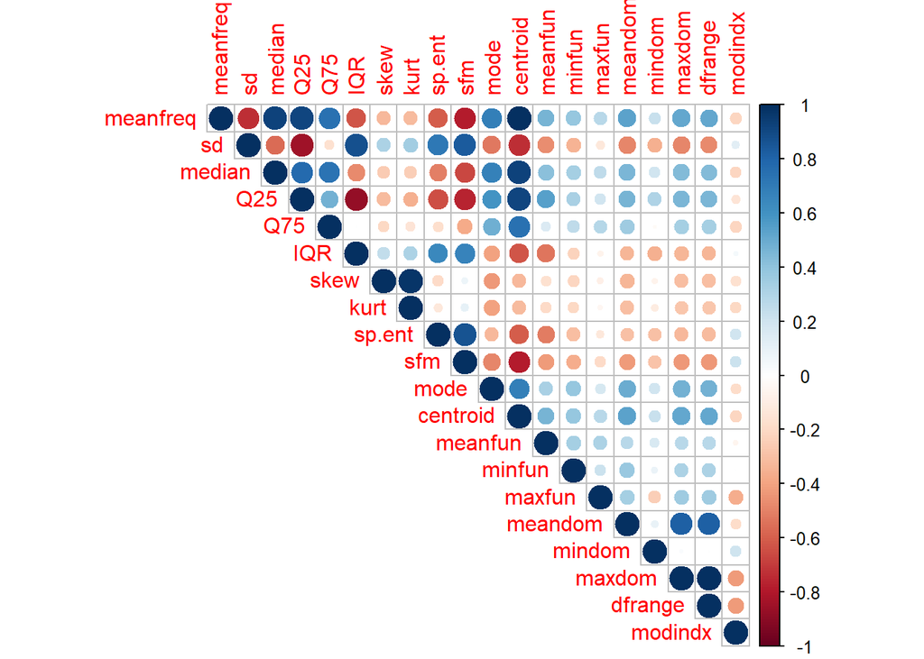

```r
#install.packages(corrplot)
library(corrplot)
corrplot(cor(datos2), type = "upper", method="circle")
```

#Usando metodo de seleccion grafico

```r
ggplot(datos, aes_string('meanfreq', fill = 'genero')) +
geom_density( alpha = .85) +
theme_minimal() +
theme(text = element_text(size=15)) +
scale_fill_manual(values = define.colores(length(levels(datos[,'genero'])))) +
labs(title = 'Densidad de la variable meanfreq según genero', y = '', x = '') +
theme(legend.position = 'top', legend.title = element_blank(), text = element_text(size = 15))
```

```
## Error in define.colores(length(levels(datos[, "genero"]))): could not find function "define.colores"
```

```r
ggplot(datos, aes_string('sd', fill = 'genero')) +
geom_density( alpha = .85) +
theme_minimal() +
theme(text = element_text(size=15)) +
scale_fill_manual(values = define.colores(length(levels(datos[,'genero'])))) +
labs(title = 'Densidad de la variable sd según genero', y = '', x = '') +
theme(legend.position = 'top', legend.title = element_blank(), text = element_text(size = 15))
```

```
## Error in define.colores(length(levels(datos[, "genero"]))): could not find function "define.colores"
```

```r
#
```

```r
ggplot(datos, aes_string('median', fill = 'genero')) +
geom_density( alpha = .85) +
theme_minimal() +
theme(text = element_text(size=15)) +
scale_fill_manual(values = define.colores(length(levels(datos[,'genero'])))) +
labs(title = 'Densidad de la variable median según genero', y = '', x = '') +
theme(legend.position = 'top', legend.title = element_blank(), text = element_text(size = 15))
```

```
## Error in define.colores(length(levels(datos[, "genero"]))): could not find function "define.colores"
```

```r
#
```

```r
ggplot(datos, aes_string('Q25', fill = 'genero')) +
geom_density( alpha = .85) +
theme_minimal() +
theme(text = element_text(size=15)) +
scale_fill_manual(values = define.colores(length(levels(datos[,'genero'])))) +
labs(title = 'Densidad de la variable Q25 según genero', y = '', x = '') +
theme(legend.position = 'top', legend.title = element_blank(), text = element_text(size = 15))
```

```
## Error in define.colores(length(levels(datos[, "genero"]))): could not find function "define.colores"
```

```r
ggplot(datos, aes_string('Q75', fill = 'genero')) +
geom_density( alpha = .85) +
theme_minimal() +
theme(text = element_text(size=15)) +
scale_fill_manual(values = define.colores(length(levels(datos[,'genero'])))) +
labs(title = 'Densidad de la variable Q75 según genero', y = '', x = '') +
theme(legend.position = 'top', legend.title = element_blank(), text = element_text(size = 15))
```

```
## Error in define.colores(length(levels(datos[, "genero"]))): could not find function "define.colores"
```

```r
ggplot(datos, aes_string('IQR', fill = 'genero')) +
geom_density( alpha = .85) +
theme_minimal() +
theme(text = element_text(size=15)) +
scale_fill_manual(values = define.colores(length(levels(datos[,'genero'])))) +
labs(title = 'Densidad de la variable IQR según genero', y = '', x = '') +
theme(legend.position = 'top', legend.title = element_blank(), text = element_text(size = 15))
```

```
## Error in define.colores(length(levels(datos[, "genero"]))): could not find function "define.colores"
```

```r
#
```

```r
ggplot(datos, aes_string('skew', fill = 'genero')) +
geom_density( alpha = .85) +
theme_minimal() +
theme(text = element_text(size=15)) +
scale_fill_manual(values = define.colores(length(levels(datos[,'genero'])))) +
labs(title = 'Densidad de la variable skew según genero', y = '', x = '') +
theme(legend.position = 'top', legend.title = element_blank(), text = element_text(size = 15))
```

```
## Error in define.colores(length(levels(datos[, "genero"]))): could not find function "define.colores"
```

```r
#
```

```r
ggplot(datos, aes_string('kurt', fill = 'genero')) +
geom_density( alpha = .85) +
theme_minimal() +
theme(text = element_text(size=15)) +
scale_fill_manual(values = define.colores(length(levels(datos[,'genero'])))) +
labs(title = 'Densidad de la variable kurt según genero', y = '', x = '') +
theme(legend.position = 'top', legend.title = element_blank(), text = element_text(size = 15))
```

```
## Error in define.colores(length(levels(datos[, "genero"]))): could not find function "define.colores"
```

```r
#
```

```r
ggplot(datos, aes_string('sp.ent', fill = 'genero')) +
geom_density( alpha = .85) +
theme_minimal() +
theme(text = element_text(size=15)) +
scale_fill_manual(values = define.colores(length(levels(datos[,'genero'])))) +
labs(title = 'Densidad de la variable sp.ent según genero', y = '', x = '') +
theme(legend.position = 'top', legend.title = element_blank(), text = element_text(size = 15))
```

```
## Error in define.colores(length(levels(datos[, "genero"]))): could not find function "define.colores"
```

```r
#
```

```r
ggplot(datos, aes_string('sfm', fill = 'genero')) +
geom_density( alpha = .85) +
theme_minimal() +
theme(text = element_text(size=15)) +
scale_fill_manual(values = define.colores(length(levels(datos[,'genero'])))) +
labs(title = 'Densidad de la variable sfm según genero', y = '', x = '') +
theme(legend.position = 'top', legend.title = element_blank(), text = element_text(size = 15))
```

```
## Error in define.colores(length(levels(datos[, "genero"]))): could not find function "define.colores"
```

```r
#
```

```r
ggplot(datos, aes_string('mode', fill = 'genero')) +
geom_density( alpha = .85) +
theme_minimal() +
theme(text = element_text(size=15)) +
scale_fill_manual(values = define.colores(length(levels(datos[,'genero'])))) +
labs(title = 'Densidad de la variable mode según genero', y = '', x = '') +
theme(legend.position = 'top', legend.title = element_blank(), text = element_text(size = 15))
```

```
## Error in define.colores(length(levels(datos[, "genero"]))): could not find function "define.colores"
```

```r
#
```

```r
ggplot(datos, aes_string('centroid', fill = 'genero')) +
geom_density( alpha = .85) +
theme_minimal() +
theme(text = element_text(size=15)) +
scale_fill_manual(values = define.colores(length(levels(datos[,'genero'])))) +
labs(title = 'Densidad de la variable centroid según genero', y = '', x = '') +
theme(legend.position = 'top', legend.title = element_blank(), text = element_text(size = 15))
```

```
## Error in define.colores(length(levels(datos[, "genero"]))): could not find function "define.colores"
```

```r
#
```

```r
ggplot(datos, aes_string('meanfun', fill = 'genero')) +
geom_density( alpha = .85) +
theme_minimal() +
theme(text = element_text(size=15)) +
scale_fill_manual(values = define.colores(length(levels(datos[,'genero'])))) +
labs(title = 'Densidad de la variable meanfun según genero', y = '', x = '') +
theme(legend.position = 'top', legend.title = element_blank(), text = element_text(size = 15))
```

```
## Error in define.colores(length(levels(datos[, "genero"]))): could not find function "define.colores"
```

```r
#
```

```r
ggplot(datos, aes_string('minfun', fill = 'genero')) +
geom_density( alpha = .85) +
theme_minimal() +
theme(text = element_text(size=15)) +
scale_fill_manual(values = define.colores(length(levels(datos[,'genero'])))) +
labs(title = 'Densidad de la variable minfun según genero', y = '', x = '') +
theme(legend.position = 'top', legend.title = element_blank(), text = element_text(size = 15))
```

```
## Error in define.colores(length(levels(datos[, "genero"]))): could not find function "define.colores"
```

```r
#
```

```r
ggplot(datos, aes_string('maxfun', fill = 'genero')) +
geom_density( alpha = .85) +
theme_minimal() +
theme(text = element_text(size=15)) +
scale_fill_manual(values = define.colores(length(levels(datos[,'genero'])))) +
labs(title = 'Densidad de la variable maxfun según genero', y = '', x = '') +
theme(legend.position = 'top', legend.title = element_blank(), text = element_text(size = 15))
```

```
## Error in define.colores(length(levels(datos[, "genero"]))): could not find function "define.colores"
```

```r
#
```

```r
ggplot(datos, aes_string('meandom', fill = 'genero')) +
geom_density( alpha = .85) +
theme_minimal() +
theme(text = element_text(size=15)) +
scale_fill_manual(values = define.colores(length(levels(datos[,'genero'])))) +
labs(title = 'Densidad de la variable meandom según genero', y = '', x = '') +
theme(legend.position = 'top', legend.title = element_blank(), text = element_text(size = 15))
```

```
## Error in define.colores(length(levels(datos[, "genero"]))): could not find function "define.colores"
```

```r
#
```

```r
ggplot(datos, aes_string('mindom', fill = 'genero')) +
geom_density( alpha = .85) +
theme_minimal() +
theme(text = element_text(size=15)) +
scale_fill_manual(values = define.colores(length(levels(datos[,'genero'])))) +
labs(title = 'Densidad de la variable mindom según genero', y = '', x = '') +
theme(legend.position = 'top', legend.title = element_blank(), text = element_text(size = 15))
```

```
## Error in define.colores(length(levels(datos[, "genero"]))): could not find function "define.colores"
```

```r
#
```

```r
ggplot(datos, aes_string('maxdom', fill = 'genero')) +
geom_density( alpha = .85) +
theme_minimal() +
theme(text = element_text(size=15)) +
scale_fill_manual(values = define.colores(length(levels(datos[,'genero'])))) +
labs(title = 'Densidad de la variable maxdom según genero', y = '', x = '') +
theme(legend.position = 'top', legend.title = element_blank(), text = element_text(size = 15))
```

```
## Error in define.colores(length(levels(datos[, "genero"]))): could not find function "define.colores"
```

```r
#
```

```r
ggplot(datos, aes_string('dfrange', fill = 'genero')) +
geom_density( alpha = .85) +
theme_minimal() +
theme(text = element_text(size=15)) +
scale_fill_manual(values = define.colores(length(levels(datos[,'genero'])))) +
labs(title = 'Densidad de la variable dfrange según genero', y = '', x = '') +
theme(legend.position = 'top', legend.title = element_blank(), text = element_text(size = 15))
```

```
## Error in define.colores(length(levels(datos[, "genero"]))): could not find function "define.colores"
```

```r
#
```

```r
ggplot(datos, aes_string('modindx', fill = 'genero')) +
geom_density( alpha = .85) +
theme_minimal() +
theme(text = element_text(size=15)) +
scale_fill_manual(values = define.colores(length(levels(datos[,'genero'])))) +
labs(title = 'Densidad de la variable modindx según genero', y = '', x = '') +
theme(legend.position = 'top', legend.title = element_blank(), text = element_text(size = 15))
```

```
## Error in define.colores(length(levels(datos[, "genero"]))): could not find function "define.colores"
```

```r
#
```

#Inicialmente se utiliza todo el dataset ya que es exploratorio, 56 por ser la raiz cuadrada(df) #Se denota un poder predictivo alto, segun el error probable de missclassification #Ademas se indican k=6, se debe usar nucleo optimal

```r
modelo<-train.kknn(genero~.,data=datos,kmax=56)
modelo #
```

```
##
## Call:
## train.kknn(formula = genero ~ ., data = datos, kmax = 56)
##
## Type of response variable: nominal
## Minimal misclassification: 0.02209596
## Best kernel: optimal
## Best k: 6
```

```r
#
```

##¿Es este problema equilibrado o desequilibrado? Justifique su respuesta.

#El problema es equilibrado, en ambos generos se presenta una muestra de igual tamano

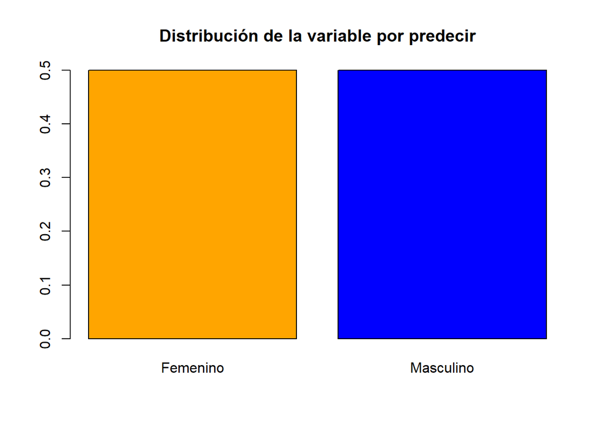

```r
barplot(prop.table(table(datos$genero)),col=c("orange","blue"),main="Distribución de la variable por predecir")
```

```r
#
```

##Use el metodo de K vecinos mas cercanos en R (con los parametros por defecto, de decir, K maximo = 20, nucleo optimal y Escalar Datos en TRUE) para generar un modelo predictivo para la tabla voces.csv usando el 80 % de los datos para la tabla aprendizaje y un 20 % para la tabla testing, luego calcule para los datos de testing la matriz de confusion, la precisi´on global y la precision para cada una de las dos categorıas. ¿Son buenos los resultados? Explique.

```r
modelo<-train.kknn(genero~.,data=datos,kmax=20, kernel = "optimal")
modelo
```

```
##
## Call:
## train.kknn(formula = genero ~ ., data = datos, kmax = 20, kernel = "optimal")
##
## Type of response variable: nominal
## Minimal misclassification: 0.02209596
## Best kernel: optimal
## Best k: 6
```

```r
tam<-dim(datos)
n<-tam[1]
n
```

```
## [1] 3168
```

```r
muestra <- sample(1:n,floor(n*0.2))
ttesting <- datos[muestra,]
taprendizaje <- datos[-muestra,]
# train.kknn escoje el k usando leave-one-out crossvalidation
modelo<-train.kknn(genero~.,data=taprendizaje,kmax=floor(sqrt(n)))
modelo
```

```
##
## Call:
## train.kknn(formula = genero ~ ., data = taprendizaje, kmax = floor(sqrt(n)))
##
## Type of response variable: nominal
## Minimal misclassification: 0.02366864
## Best kernel: optimal
## Best k: 1
```

```r
prediccion<-predict(modelo,ttesting[,-21])
prediccion
```

```
##   [1] Femenino  Masculino Femenino  Femenino  Masculino Masculino Masculino
##   [8] Masculino Femenino  Masculino Masculino Masculino Femenino  Femenino
##  [15] Femenino  Femenino  Femenino  Masculino Femenino  Masculino Masculino
##  [22] Masculino Masculino Femenino  Femenino  Femenino  Masculino Masculino
##  [29] Masculino Femenino  Femenino  Masculino Masculino Masculino Masculino
##  [36] Femenino  Femenino  Masculino Masculino Femenino  Masculino Femenino
##  [43] Masculino Masculino Masculino Femenino  Femenino  Femenino  Masculino
##  [50] Masculino Femenino  Femenino  Masculino Masculino Femenino  Masculino
##  [57] Femenino  Masculino Femenino  Femenino  Masculino Femenino  Femenino
##  [64] Femenino  Masculino Masculino Femenino  Femenino  Masculino Masculino
##  [71] Masculino Femenino  Masculino Masculino Femenino  Masculino Masculino
##  [78] Femenino  Masculino Femenino  Masculino Femenino  Masculino Masculino
##  [85] Masculino Femenino  Masculino Femenino  Femenino  Femenino  Masculino
##  [92] Femenino  Masculino Masculino Masculino Masculino Masculino Masculino
##  [99] Femenino  Masculino Masculino Masculino Masculino Femenino  Femenino
```

[output cut: 77 more lines]

```r
## Matriz de Confusión
MC<-table(ttesting[,21],prediccion)
# Índices de Calidad de la predicción
indices.general(MC)
```

```
## $`Matriz de Confusión`
##            prediccion
##             Femenino Masculino
##   Femenino       311        18
##   Masculino        7       297
##
## $`Precisión Global`
## [1] 0.9605055
##
## $`Error Global`
## [1] 0.03949447
##
## $`Precisión por categoría`
##  Femenino Masculino
## 0.9452888 0.9769737
##
## $`Precision Positiva`
## [1] 0.9769737
##
## $`Precision Negativa`
## [1] 0.9452888
##
## $`Falsos Positivos`
## [1] 0.05471125
##
## $`Falsos Negativos`
## [1] 0.02302632
##
## $`Asertividad Positiva`
## [1] 0.9428571
##
## $`Asertividad Negativa`
## [1] 0.9779874
```

##Repita el item d), pero esta vez, seleccione las 6 variables que, segun su criterio, tienen mejor poder predictivo. ¿Mejoran los resultados?

```r
modelo<-train.kknn(genero~sd+Q25+IQR+meanfun+sp.ent+sfm,data=taprendizaje,kmax=20)
modelo
```

```
##
## Call:
## train.kknn(formula = genero ~ sd + Q25 + IQR + meanfun + sp.ent +     sfm, data = taprendizaje, kmax = 20)
##
## Type of response variable: nominal
## Minimal misclassification: 0.01459566
## Best kernel: optimal
## Best k: 8
```

```r
prediccion<-predict(modelo,ttesting[,-21])
prediccion
```

```
##   [1] Femenino  Femenino  Femenino  Femenino  Masculino Masculino Masculino
##   [8] Masculino Femenino  Masculino Masculino Masculino Femenino  Femenino
##  [15] Femenino  Femenino  Femenino  Masculino Femenino  Masculino Masculino
##  [22] Masculino Masculino Femenino  Femenino  Femenino  Masculino Masculino
##  [29] Masculino Femenino  Femenino  Masculino Masculino Masculino Masculino
##  [36] Femenino  Femenino  Masculino Masculino Femenino  Masculino Femenino
##  [43] Masculino Masculino Masculino Femenino  Femenino  Femenino  Masculino
##  [50] Masculino Femenino  Femenino  Masculino Masculino Femenino  Masculino
##  [57] Femenino  Masculino Femenino  Femenino  Masculino Femenino  Femenino
##  [64] Femenino  Masculino Masculino Femenino  Femenino  Masculino Masculino
##  [71] Masculino Femenino  Masculino Masculino Femenino  Masculino Masculino
##  [78] Femenino  Masculino Femenino  Masculino Femenino  Masculino Masculino
##  [85] Masculino Femenino  Masculino Femenino  Femenino  Femenino  Masculino
##  [92] Femenino  Masculino Femenino  Masculino Masculino Masculino Masculino
##  [99] Femenino  Masculino Masculino Femenino  Masculino Femenino  Femenino
```

[output cut: 77 more lines]

```r
## Matriz de Confusión
MC<-table(ttesting[,21],prediccion)
# Índices de Calidad de la predicción
indices.general(MC)
```

```
## $`Matriz de Confusión`
##            prediccion
##             Femenino Masculino
##   Femenino       326         3
##   Masculino       12       292
##
## $`Precisión Global`
## [1] 0.9763033
##
## $`Error Global`
## [1] 0.02369668
##
## $`Precisión por categoría`
##  Femenino Masculino
## 0.9908815 0.9605263
##
## $`Precision Positiva`
## [1] 0.9605263
##
## $`Precision Negativa`
## [1] 0.9908815
##
## $`Falsos Positivos`
## [1] 0.009118541
##
## $`Falsos Negativos`
## [1] 0.03947368
##
## $`Asertividad Positiva`
## [1] 0.9898305
##
## $`Asertividad Negativa`
## [1] 0.964497
```

##Usando la funcion programada en el ejercicio 1, los datos voces.csv y los modelos generados arriba construya un DataFrame de manera que en cada una de las filas aparezca un modelo predictivo y en las columnas aparezcan los ındices Precision Global, Error Global, Precision Positiva (PP), Precision Negativa (PN), Falsos Positivos (FP), los Falsos Negativos (FN), la Asertividad Positiva (AP) y la Asertividad Negativa (AN). ¿Cual de los modelos es mejor para estos datos?